# spot_detection_MDA231

```python
import os
import matplotlib.pyplot as plt
import numpy as np
import pandas as pd
from src.feature_extraction import FeatureReader, FeaturePlotter, ImageCropper
from src import stats
```

No features are detected when there is an absence of cells. Where no channel is found, the origin of the error is not clear, as these often have many cells in view. In these cases, hdf5 output file is furthermore tiny (~15Kb).

```python
base_folder = '/Users/jcboyd/Documents/drug_screen/'
plate = '25D_20_384_20X_D_F_C3_C5_Decon_20160031_2'
ch5_folder = os.path.join(base_folder, 'cecog_out/%s/hdf5/' % plate)
output = './output/'
```

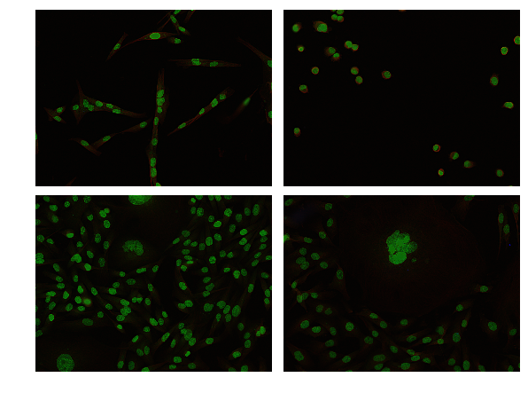

```python
"""
Visualise various positions
"""
imgs = ['E23_01', 'N24_02', 'M04_01', 'P22_04']

fig = plt.figure()

for i, img in enumerate(imgs):
    ax = fig.add_subplot(2, 2, i + 1)
    well, field = img.split('_')
    ic = ImageCropper(well, field, ch5_folder, plate)
    ic.plot_image(ax)

fig.set_figheight(7.5)
fig.set_figwidth(10)
plt.subplots_adjust(wspace=0.01, hspace=0.05)

plt.show(fig)
```

```python
"""
Metadata shows the drug and concentration administered for each well.
This is given for a single plate.
"""
metadata_folder = os.path.join(base_folder, 'metadata')
metadata_file = 'PlateMap-KPP utilisée sur MDA 231 et MDA 468(modified).xlsx'
metadata = pd.read_excel(os.path.join(metadata_folder, metadata_file))

print metadata.head(10)
```

```
                  Plate    Well Content  Concentration
0  Plate_KinInh_1_P1_P1  A - 01    DMSO            NaN
1  Plate_KinInh_1_P1_P1  A - 02    DMSO            NaN
2  Plate_KinInh_1_P1_P1  A - 03    DMSO            NaN
3  Plate_KinInh_1_P1_P1  A - 04    DMSO            NaN
4  Plate_KinInh_1_P1_P1  A - 05    DMSO            NaN
5  Plate_KinInh_1_P1_P1  A - 06    DMSO            NaN
6  Plate_KinInh_1_P1_P1  A - 07    DMSO            NaN
7  Plate_KinInh_1_P1_P1  A - 08    DMSO            NaN
8  Plate_KinInh_1_P1_P1  A - 09    DMSO            NaN
9  Plate_KinInh_1_P1_P1  A - 10    DMSO            NaN
```

```python
"""
Read all feature data
"""
features = [('primary__primary4', 'roisize'),
            ('tertiary__expanded', 'spotfeatures_count'),
            ('tertiary__expanded', 'spotfeatures_avg_intensity'),
            ('tertiary__expanded', 'granu_open_volume_1'),
            ('tertiary__expanded', 'granu_open_volume_2'),
            ('tertiary__expanded', 'granu_open_volume_3'),
            ('tertiary__expanded', 'granu_open_volume_5'),
            ('tertiary__expanded', 'granu_open_volume_7'),
            ('tertiary__expanded', 'n2_avg')]

fr = FeatureReader(plate, ch5_folder, features)
fr.read_features()
all_features = fr.all_features
```

```python
"""
Aggregate features by well
"""
agg_spot_features = fr.aggregate_wells('spotfeatures_count')
agg_roi_features = fr.aggregate_wells('roisize')
agg_intensity_features = fr.aggregate_wells('spotfeatures_avg_intensity')

agg_gran1_features = fr.aggregate_wells('granu_open_volume_1')
agg_gran2_features = fr.aggregate_wells('granu_open_volume_2')
agg_gran3_features = fr.aggregate_wells('granu_open_volume_3')
agg_gran5_features = fr.aggregate_wells('granu_open_volume_5')
agg_gran7_features = fr.aggregate_wells('granu_open_volume_7')

agg_n2_avg_features = fr.aggregate_wells('n2_avg')

agg_density_features = {well : np.array(agg_spot_features[well]) / np.array(agg_roi_features[well])
                        for well in agg_spot_features.keys()}
```

```python
"""
Aggregate all features
"""
all_spot_features = fr.aggregate_all('spotfeatures_count')
all_roi_features = fr.aggregate_all('roisize')
all_intensity_features = fr.aggregate_all('spotfeatures_avg_intensity')

all_gran1_features = fr.aggregate_all('granu_open_volume_1')
all_gran2_features = fr.aggregate_all('granu_open_volume_2')
all_gran3_features = fr.aggregate_all('granu_open_volume_3')
all_gran5_features = fr.aggregate_all('granu_open_volume_5')
all_gran7_features = fr.aggregate_all('granu_open_volume_7')

all_n2_avg_features = fr.aggregate_all('n2_avg')
all_density_features = np.array(all_spot_features) / np.array(all_roi_features)
```

```python
# Pool spot features for comparisons
dmso_wells = fr.get_wells_by_property(metadata, property={'key' : 'Content', 'value' : 'DMSO'})
dmso_pool_spot_features = fr.pool_features(dmso_wells, agg_spot_features)
dmso_pool_density_features = fr.pool_features(dmso_wells, agg_density_features)
dmso_pool_gran2_features = fr.pool_features(dmso_wells, agg_gran2_features)
dmso_pool_n2_avg_features = fr.pool_features(dmso_wells, agg_n2_avg_features)

none = fr.get_wells_by_property(metadata, property={'key' : 'Content', 'value' : 'None'})
none_pool_spot_features = fr.pool_features(none, agg_spot_features)

positive1 = fr.get_wells_by_property(metadata, property={'key' : 'Content', 'value' : 'Olaparib'})
positive1_pool_spot_features = fr.pool_features(positive1, agg_spot_features)

positive2 = fr.get_wells_by_property(metadata, property={'key' : 'Content', 'value' : 'Cisplatine'})
positive2_pool_spot_features = fr.pool_features(positive2, agg_spot_features)
```

```python
cell_totals = []
spot_density_totals = []
gran1_means = []
gran2_means = []
gran3_means = []
gran5_means = []
gran7_means = []
n2_avg_totals = []

df_export = pd.DataFrame(
    columns=(
        'well', 'content', 'total_cells', 'total_density', 'gran1_means', 'gran2_means',
        'gran3_means', 'gran5_means', 'gran7_means', 'n2_avg_totals'
    ))

for well in sorted(agg_spot_features.keys()):
    if len(agg_spot_features[well]) != 0:
        cell_totals.append(len(agg_spot_features[well]))
        spot_density_totals.append(np.mean(agg_density_features[well]))
        gran1_means.append(np.mean(agg_gran1_features[well]))
        gran2_means.append(np.mean(agg_gran2_features[well]))
        gran3_means.append(np.mean(agg_gran3_features[well]))
        gran5_means.append(np.mean(agg_gran5_features[well]))
        gran7_means.append(np.mean(agg_gran7_features[well]))
        n2_avg_totals.append(np.mean(agg_n2_avg_features[well]))

        content = fr.get_well_property(metadata, well, 'Content')
        df_export = df_export.append(
            {'well' : well,
             'content' : content,
             'total_cells' : cell_totals[-1],
             'total_density' : spot_density_totals[-1],
             'gran1_means' : gran1_means[-1],
             'gran2_means' : gran2_means[-1],
             'gran3_means' : gran3_means[-1],
             'gran5_means' : gran5_means[-1],
             'gran7_means' : gran7_means[-1],
             'n2_avg_totals' : n2_avg_totals[-1]}, ignore_index=True)
    else:
        print 'Empty well: %s (%s)' % (well,
            np.array(metadata[metadata['Well'] == well[0] + ' - ' + well[1:]]['Content'])[0])

df_export.to_csv(os.path.join(output, 'totals_mda231.tsv'), sep='\t', index=False)
```

```
Empty well: C02 (Cantharidic acid)
Empty well: C11 (Staurosporine)
Empty well: C16 (RWJ-60475 (AM)3)
Empty well: D11 (Gliotoxin)
Empty well: D13 (MG-132)
Empty well: E12 (Shikonin)
Empty well: E14 (NSC-663284)
Empty well: E20 (BVT-948)
Empty well: G02 (9,10-Phenanthrenequinone)
Empty well: H21 (N-Ethylmaleimide )
Empty well: M07 (ZM 449829)
Empty well: M09 (BAY 11-7082)
Empty well: O13 (BML-265 (Erlotinib analog))
```

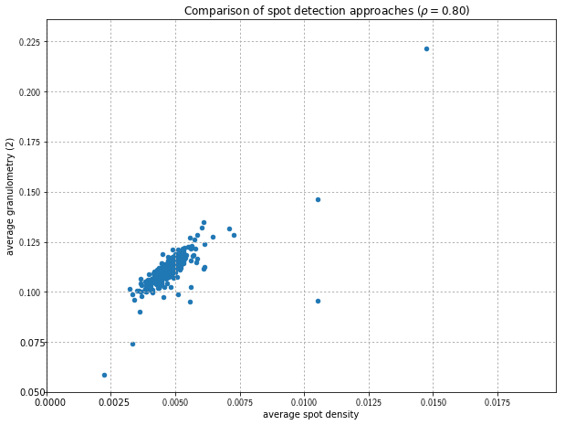

```python
"""
Comparison of spot density and granulometry features
"""
fp = FeaturePlotter()
fig, ax = plt.subplots(figsize=(10, 7.5))

fp.plot_scatter(ax, spot_density_totals, gran2_means,
                title='Comparison of spot detection approaches',
                xlabel='average spot density',
                ylabel='average granulometry (2)',
                size=20, ylim=0.05)
plt.show(fig)
```

```python
 """
Identify outlier (i.e. point with greatest perpendicular distance to trendline
i.e. dy/dx much lower than trendline gradient)
"""
for well in agg_spot_features.keys():
    if len(agg_density_features[well]) > 0 and len(agg_gran2_features[well]) > 0:
        density = np.mean(agg_density_features[well])
        granulometry = np.mean(agg_gran2_features[well])
        dydx = granulometry / density
        if dydx < 10:
            print 'Well: %s\nSpot density: %.04f\nAverage granulometry: %.04f' % (well, density, granulometry)
```

```
Well: G17
Spot density: 0.0105
Average granulometry: 0.0954
```

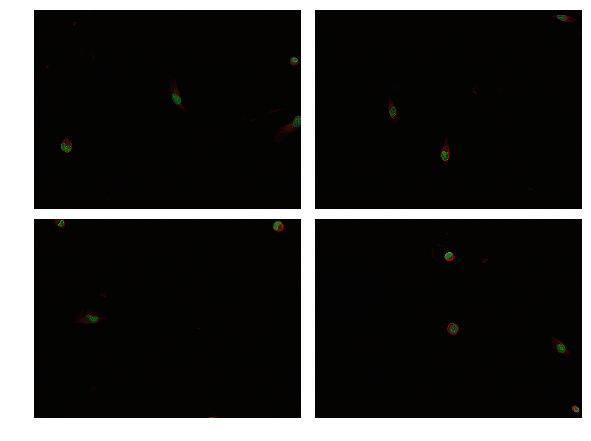

```python
"""
Visualise the four positions of the outlier (in granulometry-density
correlation) well G17. That is, an unusually dense for the given
granulometry. This is therefore where the two approaches disagree most.
"""
well = 'G17'
fig = plt.figure()

for i in range(4):
    ax = fig.add_subplot(2, 2, i + 1)
    ic = ImageCropper(well, '0%s' % (i + 1), ch5_folder, plate)
    ic.plot_image(ax)

fig.set_figheight(7.5)
fig.set_figwidth(10)
plt.subplots_adjust(wspace=0.01, hspace=0.05)

plt.show(fig)
```

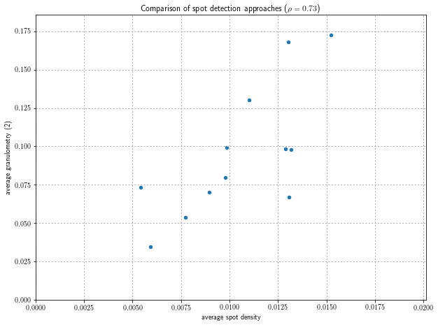

```python
"""
Comparison of spot density and granulometry features for
"""
well = 'G17'

fp = FeaturePlotter()
fig, ax = plt.subplots(figsize=(10, 7.5))

fp.plot_scatter(ax, agg_density_features[well], agg_gran2_features[well],
                title='Comparison of spot detection approaches',
                xlabel='average spot density',
                ylabel='average granulometry (2)',
                size=20)

plt.show(fig)
```

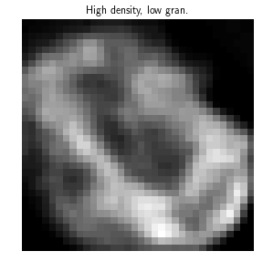

```python
well = 'G17'

channel = 'tertiary__expanded'
feature = 'spotfeatures_count'

fig = plt.figure()

for field in all_features[well]:
    for index, _ in enumerate(all_features[well][field]['roisize']):
        gran_2_feature = all_features[well][field]['granu_open_volume_2'][index]
        roi_feature = all_features[well][field]['roisize'][index]
        spot_count_feature = all_features[well][field]['spotfeatures_count'][index]

        spot_density_feature = spot_count_feature / roi_feature
        dydx =  gran_2_feature / spot_density_feature

        if dydx < 3.5:
            ic = ImageCropper(well, field, ch5_folder, plate)
            bounding_boxes = ic.get_bounding_box_list(channel)
            ax = fig.add_subplot(1, 2, 1)
            ic.plot_bounding_box(ax, ic.extract_bounding_box(bounding_boxes[index]),
                                 title='Low density, high gran.')
        if dydx > 7:
            ic = ImageCropper(well, field, ch5_folder, plate)
            bounding_boxes = ic.get_bounding_box_list(channel)
            ax = fig.add_subplot(1, 2, 2)
            ic.plot_bounding_box(ax, ic.extract_bounding_box(bounding_boxes[index]),
                                 title='High density, low gran.')

fig.set_figheight(7.5)
fig.set_figwidth(10)
plt.show()
```

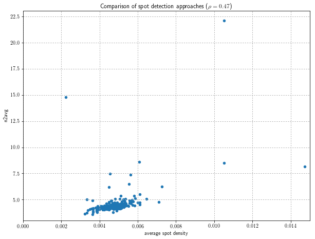

```python
fp = FeaturePlotter()
fig, ax = plt.subplots(figsize=(10, 7.5))

fp.plot_scatter(ax, spot_density_totals, n2_avg_totals,
                title='Comparison of spot detection approaches',
                xlabel='average spot density',
                ylabel='n2avg',
                size=20, xlim=[0, 0.015], ylim=3)

plt.show(fig)
```

```python
"""
Identify outliers (i.e. point with greatest perpendicular distance to trendline
i.e. dy/dx much lower than trendline gradient)
"""
for well in agg_spot_features.keys():
    if len(agg_n2_avg_features[well]) > 0 and len(agg_density_features[well]) > 0:
        n2_avg = np.mean(agg_n2_avg_features[well])
        density = np.mean(agg_density_features[well])
        dydx = n2_avg / density
        if dydx > 2000:
            print 'Well: %s\nSpot density: %.04f\nAverage granulometry: %.04f' % (well, n2_avg, density)
```

```
Well: G17
Spot density: 22.0906
Average granulometry: 0.0105
Well: G16
Spot density: 14.7758
Average granulometry: 0.0022
```

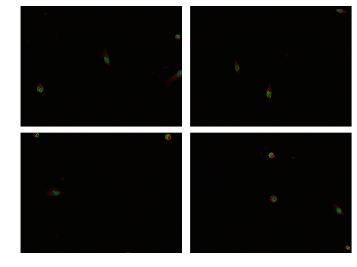

```python
"""
NB. C04 is really an empty well
"""
well = 'G17'
fig = plt.figure()

for i in range(4):
    ax = fig.add_subplot(2, 2, i + 1)
    ic = ImageCropper(well, '0%s' % (i + 1), ch5_folder, plate)
    ic.plot_image(ax)

fig.set_figheight(7.5)
fig.set_figwidth(10)
plt.subplots_adjust(wspace=0.01, hspace=0.05)

plt.show(fig)
```

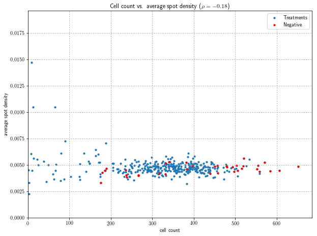

```python
"""
Compare spot count with average spot density
"""
fp = FeaturePlotter()
fig, ax = plt.subplots(figsize=(10, 7.5))

fp.plot_scatter(ax, cell_totals, spot_density_totals,
                title='Cell count vs. average spot density',
                xlabel='cell count',
                ylabel='average spot density',
                size=10)

"""
Compare DMSO spot count with average spot density
"""
dmso_cell_totals = []
dmso_spot_density_totals = []

for well in dmso_wells:
    if len(agg_spot_features[well]) != 0:
        dmso_cell_totals.append(len(agg_spot_features[well]))
        dmso_spot_density_totals.append(np.mean(agg_density_features[well]))
    else:
        print 'Empty well: %s (%s)' % (well,
            np.array(metadata[metadata['Well'] == well[0] + ' - ' + well[1:]]['Content'])[0])

ax.scatter(dmso_cell_totals, dmso_spot_density_totals, color='red', s=10)

ax.legend(['Treatments', 'Negative'])
plt.show(fig)
```

```python
# counts = [(key, len(agg_density_features[key])) for key in agg_density_features.keys()]
# counts = sorted(counts, key=lambda x: x[1])
# plot_data = [agg_density_features[count[0]] for count in counts]

# plt.boxplot([agg_density_features['G16'],
#              agg_density_features['G17'],
#              agg_density_features['E15'],
#              agg_density_features['H23'],
#              agg_density_features['P12'],
#              agg_density_features['P12'],
#              agg_density_features['J10'],
#              agg_density_features['K08']])
# plt.show()
```

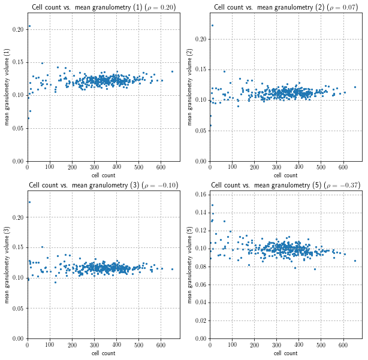

```python
"""
Compare spot count with granulometry features
"""

well = 'G01'
fp = FeaturePlotter()
fig = plt.figure()

ax = fig.add_subplot(2, 2, 1)
fp.plot_scatter(ax, cell_totals, gran1_means, title='Cell count vs. mean granulometry (1)',
                xlabel='cell count', ylabel='mean granulometry volume (1)', size=5)

ax = fig.add_subplot(2, 2, 2)
fp.plot_scatter(ax, cell_totals, gran2_means, title='Cell count vs. mean granulometry (2)',
                xlabel='cell count', ylabel='mean granulometry volume (2)', size=5)

ax = fig.add_subplot(2, 2, 3)
fp.plot_scatter(ax, cell_totals, gran3_means, title='Cell count vs. mean granulometry (3)',
                xlabel='cell count', ylabel='mean granulometry volume (3)', size=5)

ax = fig.add_subplot(2, 2, 4)
fp.plot_scatter(ax, cell_totals, gran5_means, title='Cell count vs. mean granulometry (5)',
                xlabel='cell count', ylabel='mean granulometry volume (5)', size=5)

fig.set_figheight(10)
fig.set_figwidth(10)
plt.show(fig)
```

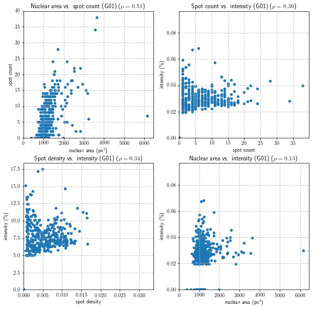

```python
well = 'G01'
fp = FeaturePlotter()
fig = plt.figure()

ax = fig.add_subplot(2, 2, 1)
fp.plot_scatter(ax, agg_roi_features[well], agg_spot_features[well],
                title='Nuclear area vs. spot count (%s)' % well,
                xlabel='nuclear area (px$^2$)', ylabel='spot count')

ax = fig.add_subplot(2, 2, 2)
fp.plot_scatter(ax, agg_spot_features[well], np.array(agg_intensity_features[well]) / 256,
                title='Spot count vs. intensity (%s)' % well,
                xlabel='spot count', ylabel=r'intensity (\%)')

ax = fig.add_subplot(2, 2, 3)
fp.plot_scatter(ax, agg_density_features[well], agg_intensity_features[well],
                title='Spot density vs. intensity (%s)' % well,
                xlabel='spot density', ylabel=r'intensity (\%)')

ax = fig.add_subplot(2, 2, 4)
fp.plot_scatter(ax, agg_roi_features[well], np.array(agg_intensity_features[well]) / 256,
                title='Nuclear area vs. intensity (%s)' % well,
                xlabel=r'nuclear area (px$^2$)', ylabel=r'intensity (\%)')

fig.set_figheight(10)
fig.set_figwidth(10)
plt.show(fig)
```

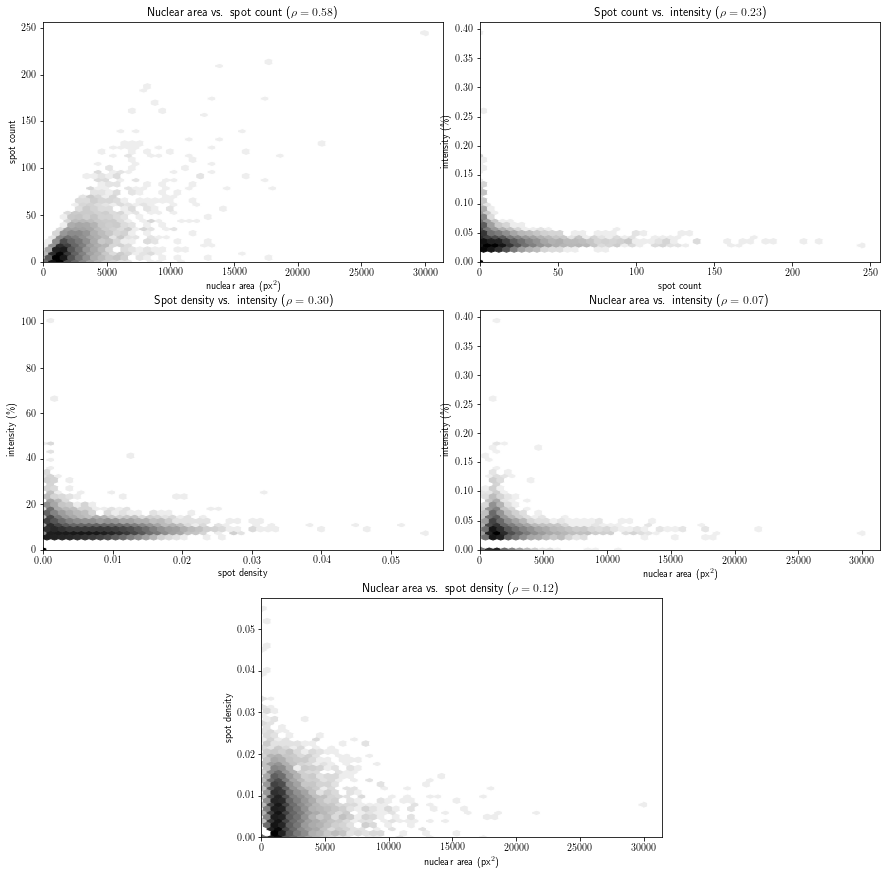

```python
import matplotlib.gridspec as gridspec
gs = gridspec.GridSpec(3, 4)

fp = FeaturePlotter()
fig = plt.figure()

ax = plt.subplot(gs[0, 0:2])
fp.plot_density(ax, all_roi_features, all_spot_features, title='Nuclear area vs. spot count',
                xlabel='nuclear area (px$^2$)', ylabel='spot count')

ax = plt.subplot(gs[0,2:])
fp.plot_density(ax, all_spot_features, np.array(all_intensity_features) / 256,
                title='Spot count vs. intensity',
                xlabel='spot count', ylabel=r'intensity (\%)')

ax = plt.subplot(gs[1,0:2])
fp.plot_density(ax, all_density_features, all_intensity_features,
                title='Spot density vs. intensity',
                xlabel='spot density', ylabel=r'intensity (\%)')

ax = plt.subplot(gs[1,2:])
fp.plot_density(ax, all_roi_features, np.array(all_intensity_features) / 256,
                title='Nuclear area vs. intensity',
                xlabel=r'nuclear area (px$^2$)', ylabel=r'intensity (\%)')

ax = plt.subplot(gs[2,1:3])
fp.plot_density(ax, all_roi_features, all_density_features,
                title='Nuclear area vs. spot density',
                xlabel=r'nuclear area (px$^2$)', ylabel=r'spot density')

fig.set_figheight(15)
fig.set_figwidth(15)
plt.show(fig)
```

The curve artefacts at the base of the cloud are the result of computing spot density on cells with a single spot, two spots, etc., giving density = $\frac{1}{area}$, $\frac{2}{area}$, etc. as area is fairly constant across cells.

```python
# outputs = './outputs/scatterplots/roi-count'

# for well in agg_spot_features.keys():
#     fp = FeaturePlotter()
#     fig = plt.figure()
#     ax = fig.add_subplot(1, 1, 1)

#     fp.plot_scatter(ax, agg_roi_features[well], agg_spot_features[well],
#                     title='Nuclear area vs. spot count (%s)' % well,
#                     xlabel='nuclear area (px$^2$)',
#                     ylabel='spot count')
#     plt.savefig(os.path.join(outputs, well))
#     plt.close()
```

```python
# outputs = './outputs/scatterplots/count-intensity'

# for well in agg_spot_features:
#     fp = FeaturePlotter()
#     fig = plt.figure()
#     ax = fig.add_subplot(1, 1, 1)

#     fp.plot_scatter(ax, agg_spot_features[well], np.array(agg_intensity_features[well]) / 256,
#                     title='Spot count vs. Intensity',
#                     xlabel='spot count',
#                     ylabel=r'Intensity (\%)')
#     plt.savefig(os.path.join(outputs, well))
#     plt.close()
```

```python
# outputs = './outputs/scatterplots/roi-intensity'

# for well in agg_roi_features:
#     fp = FeaturePlotter()
#     fig = plt.figure()
#     ax = fig.add_subplot(1, 1, 1)

#     fp.plot_scatter(ax, agg_roi_features[well], np.array(agg_intensity_features[well]) / 256,
#                     title='Nuclear area vs. intensity',
#                     xlabel=r'nuclear area (px$^2$)',
#                     ylabel=r'intensity (\%)')
#     plt.savefig(os.path.join(outputs, well))
#     plt.close()
```

```python
# outputs = './outputs/scatterplots/density-intensity'

# for well in agg_spot_features:
#     fp = FeaturePlotter()
#     fig = plt.figure()
#     ax = fig.add_subplot(1, 1, 1)

#     fp.plot_scatter(ax, agg_density_features[well], np.array(agg_intensity_features[well]) / 256,
#                     title='Density vs. intensity',
#                     xlabel='spot count',
#                     ylabel=r'intensity (\%)')
#     plt.savefig(os.path.join(outputs, well))
#     plt.close()
```

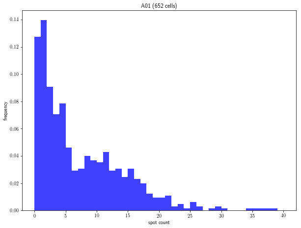

```python
"""
Sample distribution of spot count.
Recall a histogram becomes the probability density function in the limit.
"""
well = 'A01'
fp = FeaturePlotter()
fig, ax = plt.subplots(figsize=(10, 7.5))

fp.plot_frequencies(ax, agg_spot_features[well], '%s (%d cells)' % (well, len(agg_spot_features[well])))
plt.show(fig)
```

```python
# outputs = './outputs/histograms'

# for well in agg_spot_features:
#     fp = FeaturePlotter()
#     fig = plt.figure()
#     ax = fig.add_subplot(1, 1, 1)
#     fp.plot_frequencies(ax, agg_spot_features[well], '%s (%d cells)' % (well, len(agg_spot_features[well])))
#     plt.savefig(os.path.join(outputs, well))
#     plt.close()
```

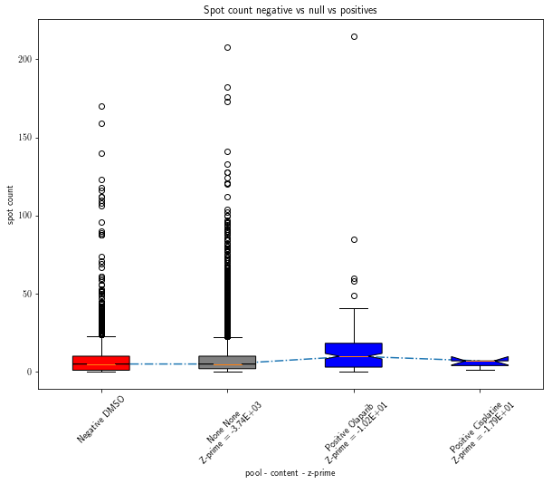

```python
pools = ['Negative', 'None', 'Positive', 'Positive']
pool_contents = ['DMSO', 'None', 'Olaparib', 'Cisplatine']
pool_features = [dmso_pool_spot_features, none_pool_spot_features,
                 positive1_pool_spot_features, positive2_pool_spot_features]

pool_colours = ['red', 'gray', 'blue', 'blue']

z_values = [stats.z_prime(dmso_pool_spot_features, features) for features in pool_features]
tick_labels = ['%s %s \nZ-prime = %.2E' % (pool, pool_contents[i], z_values[i]) for i,
               pool in enumerate(pools)]
tick_labels[0] = 'Negative DMSO'

fp = FeaturePlotter()
fig, ax = plt.subplots(figsize=(10, 7.5))

fp.plot_box(ax, features=pool_features, tick_labels=tick_labels, colours=pool_colours,
            title='Spot count negative vs null vs positives ',
            xlabel='pool - content - z-prime', ylabel='spot count')

plt.show(fig)
```

```python
stats.z_prime(dmso_pool_spot_features, agg_spot_features['G17'])
```

```
-2.6292377559964106
```

```python
non_empty_wells = filter(lambda well: not not agg_spot_features[well], agg_spot_features.keys())
compare_wells = filter(lambda well: not well in dmso_wells and not well in none, non_empty_wells)
```

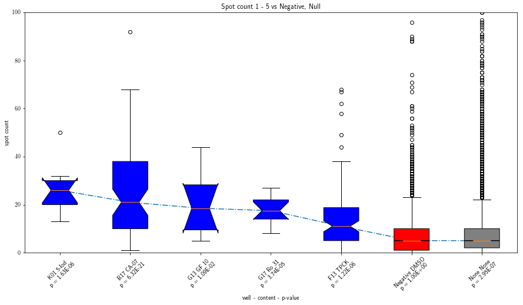

```python
ranks = (0, 5)
ranked_wells = sorted(compare_wells, key=lambda well: np.median(agg_spot_features[well]), reverse=True)

# Collect top ranked wells
top_wells = ranked_wells[ranks[0]:ranks[1]]
top_wells_content = [fr.get_well_property(metadata, well, 'Content')[0:5] for well in top_wells]
top_wells_features = [agg_spot_features[well] for well in top_wells]
colours = ['blue']*len(top_wells)

# Append specific wells
top_wells.extend(['Negative', 'None'])
top_wells_content.extend(['DMSO', 'None'])
top_wells_features.extend([dmso_pool_spot_features, none_pool_spot_features])
colours.extend(['red', 'gray'])

p_values = [stats.kolgomorov_smirnov(dmso_pool_spot_features, features) for features in top_wells_features]
tick_labels = ['%s %s \np = %.2E' % (well, top_wells_content[i], p_values[i]) for i, well in enumerate(top_wells)]

fp = FeaturePlotter()
fig, ax = plt.subplots(figsize=(15, 7.5))

fp.plot_box(ax, features=top_wells_features, tick_labels=tick_labels, colours=colours,
            title='Spot count %s - %s vs Negative, Null' % (ranks[0] + 1, ranks[1]),
            xlabel='well - content - p-value',
            ylabel='spot count')
ax.set_ylim([0, 100])

plt.show(fig)
```

```python
non_empty_wells = filter(lambda well: not not agg_spot_features[well], agg_spot_features.keys())
compare_wells = filter(lambda well: not well in dmso_wells and not well in none, non_empty_wells)

BONFERRONI_THRESHOLD = stats.P_VALUE_THRESHOLD / len(compare_wells)
```

Here we rank those experiments with a statistically significant p-value, adjusting for multiple testing with a Bonferroni correction.